# Visualization

BIOS 6301 · Lecture with discussion questions

Department of Biostatistics, Vanderbilt University Medical Center

Session 8

## Where we are

| Course arc | Sessions |  |
| --- | --- | --- |
| Setup and workflow | 0–2 |  |
| **Data foundations** | **3–8** | **← today** |
| Modern tools | 9–10 |  |
| R programming | 11–13 |  |
| Statistical computing | 14–16 |  |

Today’s deck develops one part of the current arc; later-session tools are named only when they clarify where this idea will be used.

## What you will be able to do

1 **Read** base-R plotting code and produce a fast diagnostic panel with it.

2 **Name** the components of the grammar of graphics and map an existing figure onto them.

3 **Build** a plot in layers — distributions, comparisons, relationships, and **uncertainty**.

4 **Control** facets, scales, transformations, and position adjustments.

5 **Apply** the perceptual hierarchy and a colour-blind-safe palette on purpose.

6 **Critique** a figure against explicit criteria — including your own.

7 **Export** a publication figure reproducibly at a stated size and resolution.

## Roadmap for today

|  | Block | Minutes |
| --- | --- | --- |
| 1 | Base R plots and annotations | 25 |
| 2 | Build a first ggplot | 12 |
| 3 | Choose displays for distributions and groups | 12 |
| 4 | Add summaries and uncertainty | 10 |
| 5 | Show repeated visits | 10 |
| 6 | Refine scales and display choices | 6 |
| 7 | Critique and improve a figure | 8 |
| 8 | Export and summary | 7 |

Figures are generated from R code when this deck renders. Optional reference slides provide extra examples for review.

**Question pauses:** predict, compare ideas, then reveal the answer.

# 1 · Base R graphics

## The teaching data

All observations in this session are **synthetic**.

| id | arm | age | sbp_0 | sbp_12 |
| --- | --- | --- | --- | --- |
| P001 | Placebo | 47 | 160 | 144 |
| P002 | Placebo | 59 | 162 | 156 |
| P003 | Placebo | 61 | 157 | 156 |
| P004 | Placebo | 48 | 157 | 163 |

- One row represents one participant.
- `sbp_0` and `sbp_12` are systolic blood pressure at baseline and week 12, in mmHg.
- `trial_long` has one row per participant per visit, as in Session 7.

## A plot starts with a question

| Question | Useful starting plot |
| --- | --- |
| What values and unusual observations occur? | Histogram or dot plot |
| How do participant values differ by arm? | Boxplot with individual points |
| How does baseline relate to follow-up? | Scatterplot |
| How does one participant change over time? | Connected points, grouped by ID |
| How many participants come from each site? | Bar chart of counts |

The same plotting function may answer different questions. Labels and the observation unit tell the reader which question you mean.

## A labelled scatterplot in base R

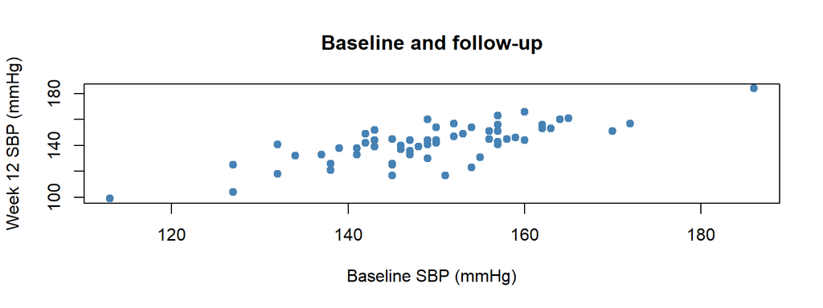

```r
plot(trial$sbp_0, trial$sbp_12,
     xlab = "Baseline SBP (mmHg)",
     ylab = "Week 12 SBP (mmHg)",
     main = "Baseline and follow-up",
     pch = 19, col = "steelblue")
```

`plot(x, y)` puts the first numeric vector on x and the second on y.

## Common base R plotting arguments

| Argument | Meaning | Example |
| --- | --- | --- |
| `pch` | Point symbol | `pch = 19` for a filled circle |
| `col` | Colour | `col = "steelblue"` |
| `cex` | Symbol/text size multiplier | `cex = 1.3` |
| `lty`, `lwd` | Line pattern and width | `lty = 2, lwd = 2` |
| `xlab`, `ylab`, `main` | Axis labels and title | `ylab = "SBP (mmHg)"` |
| `xlim`, `ylim` | Display limits | `ylim = c(90, 190)` |

Use `?plot.default` and `?par` to look up options as needed.

## Which participant has lower follow-up SBP?

60 SECONDS · THINK, THEN VOTE

The scatterplot has **baseline SBP on x** and **week-12 SBP on y**.

Imagine a line where **y = x**.

**A.** A point above the line

**B.** A point below the line

**C.** A point on the line

**B.** Below the line, week-12 SBP is lower than baseline.

On the line, the two measurements are equal.

## Adding a reference line

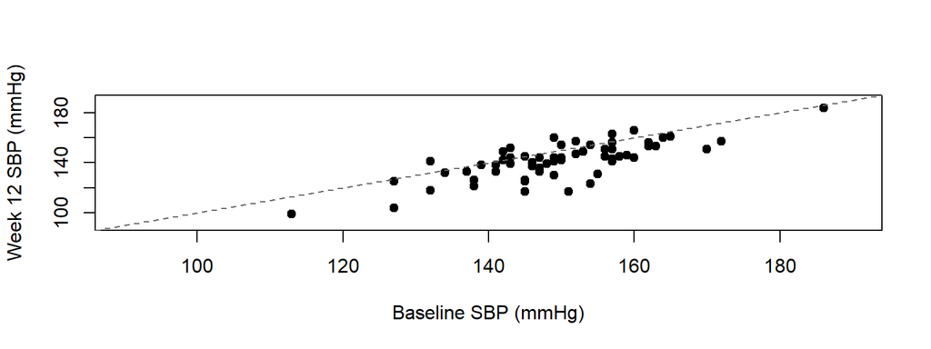

```r
plot(trial$sbp_0, trial$sbp_12,
     xlab = "Baseline SBP (mmHg)", ylab = "Week 12 SBP (mmHg)",
     xlim = c(90, 190), ylim = c(90, 190), pch = 19)
abline(a = 0, b = 1, lty = 2, col = "grey40")
```

`a` is the intercept and `b` is the slope. Below the line, follow-up is lower than baseline. This line represents equality, not a fitted regression.

## Colours and a legend by treatment arm

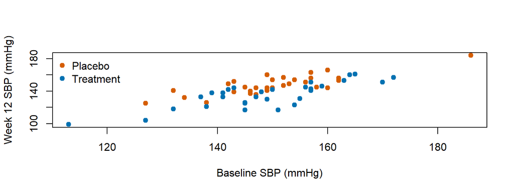

```r
plot(trial$sbp_0, trial$sbp_12, pch = 19,
     col = arm_col[trial$arm],
     xlab = "Baseline SBP (mmHg)", ylab = "Week 12 SBP (mmHg)")
legend("topleft", legend = names(arm_col),
       col = arm_col, pch = 19, bty = "n")
```

`arm_col` is a named vector: `c(Placebo = "#D55E00", Treatment = "#0072B2")`. Indexing it by arm assigns the same colour consistently.

## New plot or added marks?

| Creates a new plot | Adds to the current plot |
| --- | --- |
| `plot()` | `points()` |
| `hist()` | `lines()` |
| `boxplot()` | `abline()` |
| `barplot()` | `text()`, `legend()` |

For example, `points(x, y, col = "red")` adds observations to existing axes. Calling `plot(x, y)` again normally starts a new plot.

## Connected measurements from one participant

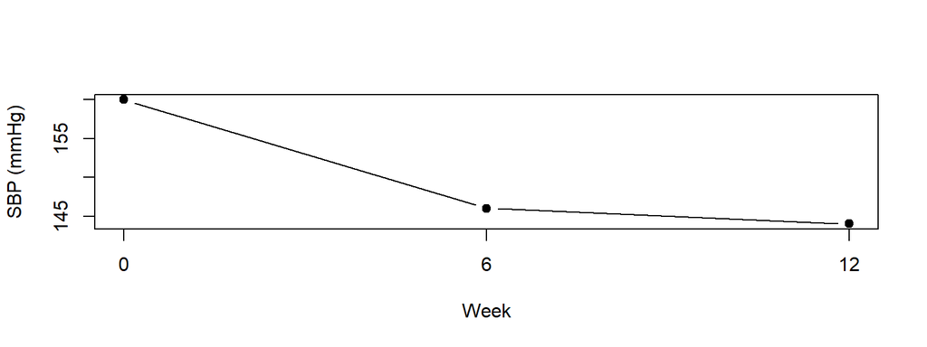

```r
weeks <- c(0, 6, 12)
values <- c(trial$sbp_0[1], trial$sbp_6[1], trial$sbp_12[1])
plot(weeks, values, type = "b", pch = 19,
     xlab = "Week", ylab = "SBP (mmHg)", xaxt = "n")
axis(1, at = weeks)
```

`type = "p"` draws points, `"l"` draws lines, and `"b"` draws both. Base R connects points in supplied order, so arrange time first.

## Histogram bins change the picture

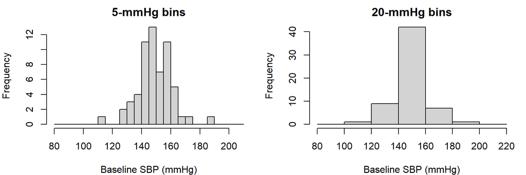

```r
saved_par <- par(mfrow = c(1, 2), mar = c(4, 4, 2, 1))
hist(trial$sbp_0, breaks = seq(80, 210, 5),
     main = "5-mmHg bins", xlab = "Baseline SBP (mmHg)")
hist(trial$sbp_0, breaks = seq(80, 220, 20),
     main = "20-mmHg bins", xlab = "Baseline SBP (mmHg)")
```

```r
par(saved_par)
```

A vector in `breaks` specifies bin boundaries. A single number requests an approximate number of bins. A pattern should not depend on one convenient choice.

## Different bins, different participants?

60 SECONDS · THINK, THEN COMPARE

The previous slide showed the same baseline SBP values in **5-mmHg** and **20-mmHg** bins.

**Did the participants change, or did the grouping of values change?**

Tell your neighbor one pattern that could look different.

The observations stayed the same. Only the bin boundaries changed.

Apparent peaks and gaps can change. Check more than one reasonable bin width.

## Boxplots with participant-level values

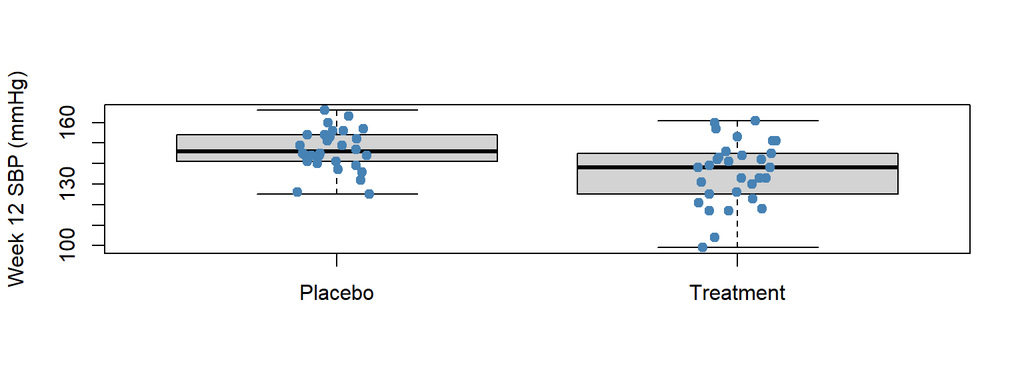

```r
boxplot(sbp_12 ~ arm, data = trial, outline = FALSE,
        ylab = "Week 12 SBP (mmHg)", xlab = "")
stripchart(sbp_12 ~ arm, data = trial,
           vertical = TRUE, method = "jitter",
           pch = 19, col = "steelblue", add = TRUE)
```

## Bar charts use counts or summaries

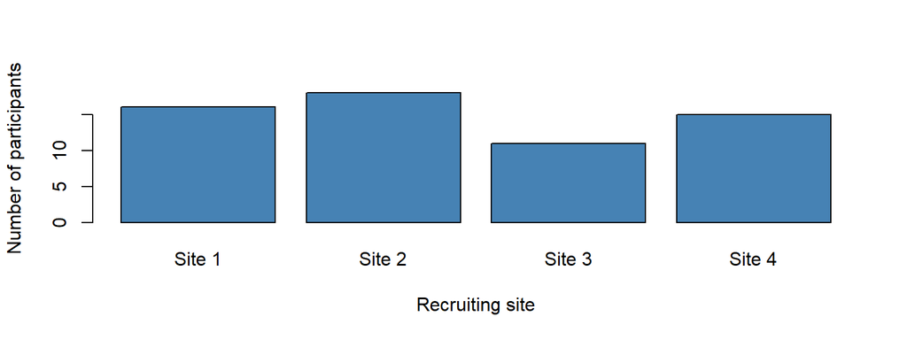

```r
site_counts <- table(trial$site_f)
barplot(site_counts, col = "steelblue",
        xlab = "Recruiting site", ylab = "Number of participants")
```

`table()` calculates the counts. `barplot()` draws their heights. A histogram instead bins a numeric variable such as blood pressure.

## Optional: two distribution diagnostics

| Plot | What it shows | How to read it |
| --- | --- | --- |
| **Empirical CDF (ECDF)** | The observed cumulative distribution | At a given SBP, read the proportion of participants at or below it |
| **Normal Q–Q plot** | Sample quantiles against theoretical normal quantiles | Points near a straight line suggest an approximately normal distribution |

- The ECDF uses **every observation**, with no histogram bins.
- In a normal Q–Q plot, systematic curvature or tail departures suggest departures from normality.

## Optional: ECDF and normal Q–Q examples

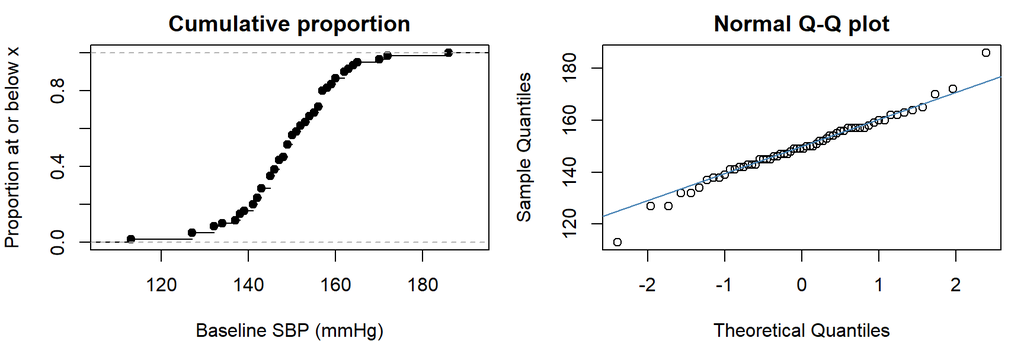

```r
saved_par <- par(mfrow = c(1, 2), mar = c(4, 4, 2, 1))
plot(ecdf(trial$sbp_0), main = "Cumulative proportion",
     xlab = "Baseline SBP (mmHg)", ylab = "Proportion at or below x")
qqnorm(trial$sbp_0, main = "Normal Q-Q plot")
qqline(trial$sbp_0, col = "steelblue")
```

```r
par(saved_par)
```

**Left:** proportion at or below each SBP value. **Right:** sample versus normal quantiles.

A roughly straight Q–Q pattern **supports approximate normality**. This is a visual assessment, without a p-value.

## Multiple panels and graphics state

```r
saved_par <- par(mfrow = c(1, 2))  # one row, two columns
hist(trial$sbp_0)
hist(trial$sbp_12)
par(saved_par)                    # restore changed settings
```

- `par()` affects the current graphics device.
- Restore settings after the multi-panel display.
- If separate panels need direct comparison, choose common axis limits.
- `par(mfrow = c(1, 1))` resets the layout, but does not reset every other option.

## Raster and vector figures

|  | PNG: raster image | PDF: vector graphics |
| --- | --- | --- |
| Stores | A grid of coloured pixels | Drawing instructions for lines, shapes, and text |
| When enlarged | Individual pixels can become visible | Vector elements remain sharp as they scale |
| Size settings | Width, height, and pixel density | Physical page width and height |

**A PDF has no single overall DPI for its vector elements.**

A PDF can also contain raster images. Those images retain their pixel-resolution limits.

## Resolution: pixels and physical size

**DPI** means dots per inch. For raster export, R uses this setting as **pixels per inch (PPI)**.

**Pixel width = width in inches × DPI**

| A 6 × 4 inch PNG | Pixel dimensions |
| --- | --- |
| 150 DPI | 900 × 600 pixels |
| 300 DPI | 1800 × 1200 pixels |
| 600 DPI | 3600 × 2400 pixels |

At fixed physical size, higher DPI creates more pixels. At fixed pixel dimensions, changing DPI changes the physical size, without adding detail.

## Saving a base R figure

```r
dir.create("output", showWarnings = FALSE)
png("output/base-sbp.png", width = 6, height = 4,
    units = "in", res = 300)
plot(trial$sbp_0, trial$sbp_12,
     xlab = "Baseline SBP (mmHg)", ylab = "Week 12 SBP (mmHg)")
dev.off()
```

The file device receives drawing commands until `dev.off()` closes it. This PNG has **1800 × 1200 pixels**: 6 × 4 inches at `res = 300`.

For a 6 × 4 inch vector PDF, open `pdf("output/base-sbp.pdf", width = 6, height = 4)` instead. **No `res` or `dpi` argument.**

## Base graphics in four functions

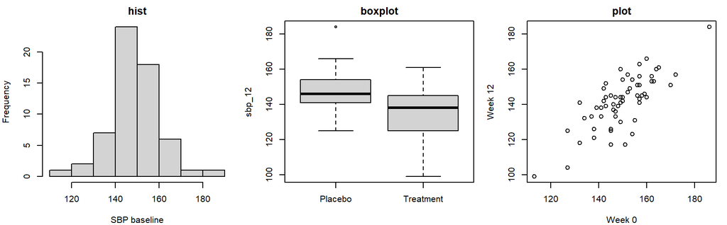

```r
par(mfrow = c(1, 3), mar = c(4, 4, 2, 1))
hist(trial$sbp_0, main = "hist", xlab = "SBP baseline")
boxplot(sbp_12 ~ arm, data = trial, main = "boxplot", xlab = "")
plot(trial$sbp_0, trial$sbp_12, main = "plot", xlab = "Week 0",
     ylab = "Week 12")
```

```r
par(mfrow = c(1, 1))
```

`par(mfrow = c(1, 3))` splits the device into a 1 × 3 grid. It is **device state**: it stays set until you change it back.

## A quick panel of distributions

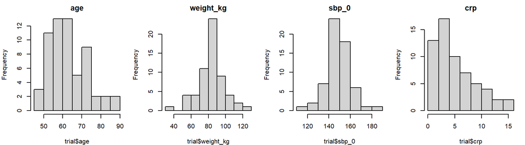

```r
par(mfrow = c(1, 4), mar = c(4, 4, 2, 1))
hist(trial$age,       main = "age")
hist(trial$weight_kg, main = "weight_kg")
hist(trial$sbp_0,     main = "sbp_0")
hist(trial$crp,       main = "crp")
```

```r
par(mfrow = c(1, 1))
```

Four columns, one screen, five seconds. You are not making a figure — you are **checking that the file is what you think it is**. `crp` is right-skewed and you now know it before you fit anything.

## Two plotting workflows

- **Base graphics:** draw to a graphics device, then add points, lines, or labels. Many functions share options such as `col`, `xlab`, and `ylim`.
- **ggplot2:** build a plot object, then add or change layers and scales. Grouping, legends, and facets follow shared rules.
- Both can produce reproducible, publication-quality figures. Choose the workflow that makes your analysis easy to understand and maintain.

# 2 · Building a first ggplot

## Our ggplot2 route

We will keep returning to the same synthetic blood-pressure study.

1. **Build a plot:** baseline versus follow-up.
2. **Choose displays:** distributions and arm comparisons.
3. **Add summaries:** means, intervals, and fitted trends.
4. **Show repeated visits:** one line per participant.
5. **Refine and export:** scales, labels, accessibility, and file size.

## A plot is a specification

**Question:** How does baseline blood pressure relate to week 12?

- **Data:** one row per participant.
- **x:** baseline SBP.
- **y:** week 12 SBP.
- **Marks:** one point per participant.

```r
ggplot(trial, aes(x = sbp_0, y = sbp_12)) +
  geom_point()
```

We describe the data and its visual mappings, then choose how to draw it.

## Seven components, plus a theme

The first four determine the data shown in a layer.

| Component | In our study |
| --- | --- |
| **Data** | Participant records in `trial` |
| **Aesthetics** | `aes(x = sbp_0, y = sbp_12)` |
| **Geom** | `geom_point()` draws each participant |
| **Stat** | Points use raw values; a histogram counts bins |

Most early examples need only data, mappings, and a geom.

## Scales, coordinates, facets, and theme

The remaining components control how the plot appears.

| Component | Role | Example |
| --- | --- | --- |
| **Scales** | Translate values to positions or colours | Logarithmic y axis |
| **Coordinates** | Define the plotting space and view | Zoom into a region |
| **Facets** | Repeat a plot for subsets | One panel per site |
| **Theme** | Style non-data elements | Fonts and grid lines |

We will add these after the basic plot answers the scientific question.

## What will this code draw?

60 SECONDS · THINK, THEN VOTE

```r
ggplot(trial, aes(sbp_0, sbp_12))
```

**A.** A scatterplot with participant points

**B.** Axes without participant points

**C.** An error

**B.** Data and mappings establish the axes.

Adding `geom_point()` draws the participant marks.

## A first ggplot: axes, then points

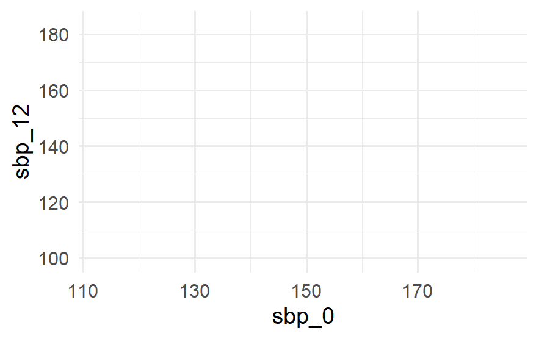

```r
ggplot(trial, aes(sbp_0, sbp_12))
```

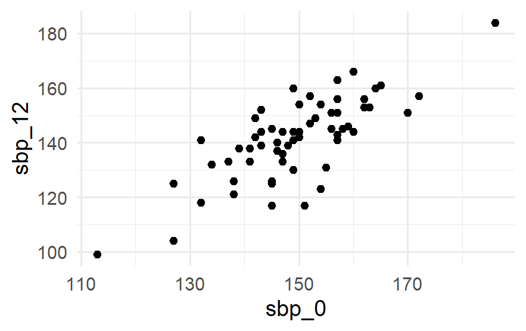

```r
ggplot(trial, aes(sbp_0, sbp_12)) +
  geom_point()
```

Data and mappings establish the axes. The geom adds visible marks.

## The pipe and the plus sign have different jobs

```r
trial |>
  filter(site == 1) |>
  ggplot(aes(sbp_0, sbp_12)) +
  geom_point() +
  labs(x = "Baseline SBP (mmHg)",
       y = "Week 12 SBP (mmHg)")
```

- `|>` passes the filtered data into `ggplot()`.
- `+` adds plotting components to the ggplot object.
- Put `+` at the end of a line when continuing the expression.
- `ggplot(...) |> geom_point()` does not mean “add a point layer.”

## A ggplot object can be revised

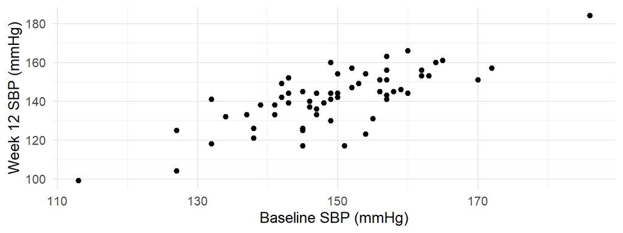

```r
p_scatter <- ggplot(trial, aes(sbp_0, sbp_12)) +
  geom_point()
p_scatter + labs(x = "Baseline SBP (mmHg)",
                 y = "Week 12 SBP (mmHg)")
```

`p_scatter + ...` displays a revised plot. To keep that version, assign it: `p_scatter <- p_scatter + labs(...)`.

## Will these points be blue?

60 SECONDS · THINK, THEN VOTE

```r
ggplot(trial, aes(sbp_0, sbp_12)) +
  geom_point(aes(colour = "blue"))
```

**A.** Yes, because the code says “blue”

**B.** It maps a category named “blue”

**C.** It cannot run

**B.** Inside `aes()`, “blue” becomes a category mapped through a colour scale.

For fixed blue points: `geom_point(colour = "blue")`.

## `aes()` means *map*. Outside means *set*

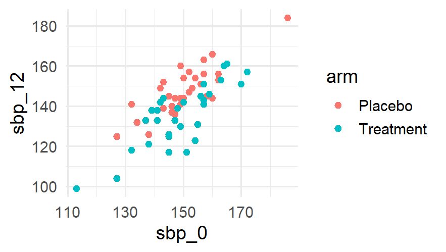

```r
ggplot(trial, aes(sbp_0, sbp_12,
                  colour = arm)) +
  geom_point()
```

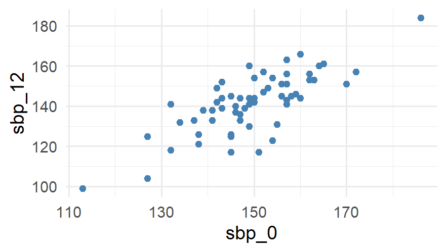

```r
ggplot(trial, aes(sbp_0, sbp_12)) +
  geom_point(colour = "steelblue")
```

Inside `aes()`: colour **carries information**, and you get a legend. Outside: colour is fixed, and this setting does not create a mapped legend.

## Colour, fill, and shape

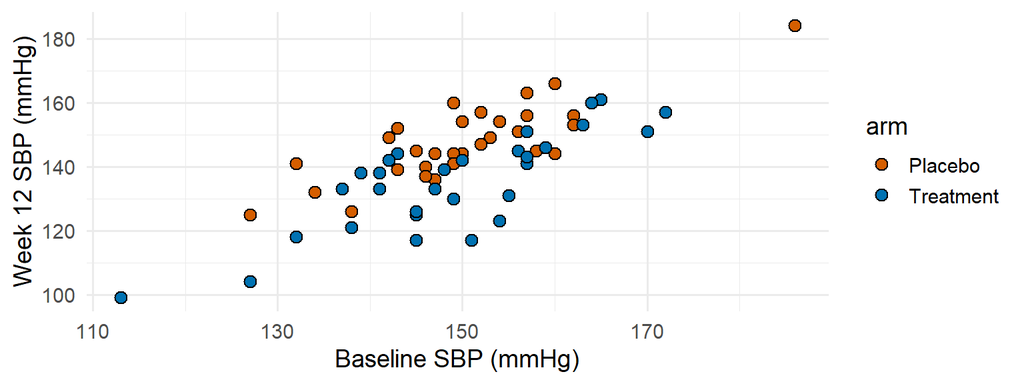

```r
ggplot(trial, aes(sbp_0, sbp_12, fill = arm)) +
  geom_point(shape = 21, colour = "black", size = 3) +
  scale_fill_manual(values = arm_col) +
  labs(x = "Baseline SBP (mmHg)", y = "Week 12 SBP (mmHg)")
```

For shapes 21–25, `fill` controls the interior and `colour` controls the border. For most other point shapes, use `colour`. For bars, `fill` colours the interior.

# 3 · Choosing a display

## Questions that need different displays

- **Distribution:** What baseline values occur?
- **Comparison:** How do week-12 values differ between arms?
- **Counts:** How many participants belong to each category?

We will keep the study data, but change the variables and marks.

## Choosing a geom

A **geom** is a layer’s drawing method: points, lines, bars, text, or another mark. Some geoms also compute a default summary before drawing.

| Your data/question | Start with |
| --- | --- |
| Two numeric measurements per person | `geom_point()` |
| One numeric variable’s distribution | `geom_histogram()` |
| A numeric outcome across groups | `geom_boxplot()` plus points |
| Counts of records by category | `geom_bar()` |
| Heights already calculated in a table | `geom_col()` |
| Repeated measurements within a person | `geom_line()` with `group = id` |

## Optional: complete ggplot2 geom catalogue

The next slides list the exported `geom_*()` functions in the ggplot2 version used to render this deck, including aliases and older interfaces.

- They are a **lookup reference**, not a memorization requirement.
- Extension-package geoms, such as `ggrepel::geom_text_repel()`, are separate.
- `stat_*()`, scales, and themes are different function families.

Skip the catalogue and continue to distributions

[Official ggplot2 function reference](https://ggplot2.tidyverse.org/reference/index.html)

## Geom reference: points and labels

| Function | Purpose |
| --- | --- |
| `geom_point()` | One mark at each x/y location |
| `geom_jitter()` | Points with position offsets to reveal overlap |
| `geom_count()` | Point area represents the number at an x/y location |
| `geom_rug()` | Small marks along the plot margins |
| `geom_text()` | Text from a label variable |
| `geom_label()` | Text with a background box |

## Geom examples: points and jitter

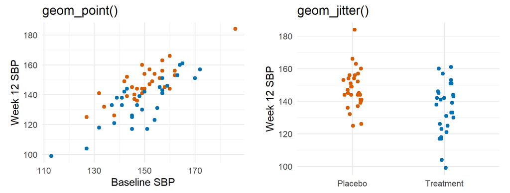

Points show a relationship between two measurements. Jitter separates overlapping observations within categories. Both show individual participants.

## Geom reference: connected observations

| Function | Purpose |
| --- | --- |
| `geom_line()` | Connect observations in x order within each group |
| `geom_path()` | Connect observations in their row order |
| `geom_step()` | Connect observations using steps |
| `geom_segment()` | Separate segments, with start and end coordinates |
| `geom_curve()` | Curved connections between endpoints |
| `geom_spoke()` | Segments specified by angle and length |

Connecting observations implies a relationship or order. It is usually inappropriate to connect unrelated participants just because their rows are adjacent.

## Geom examples: line and step

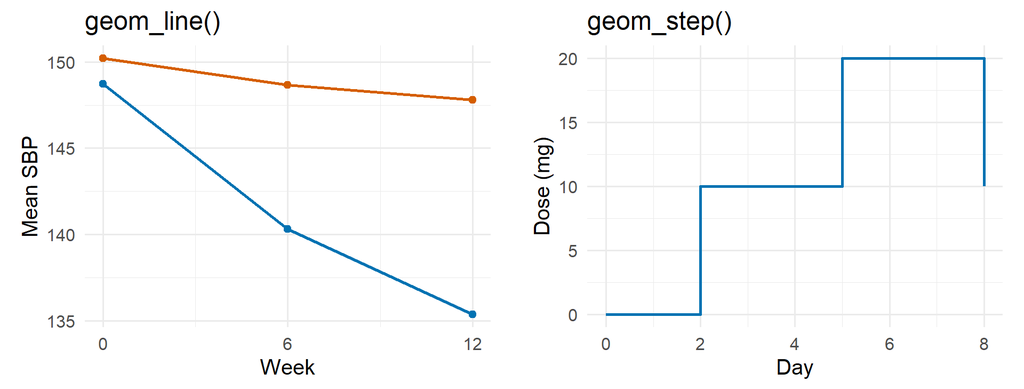

A line connects measured summaries. A step can represent a dose held constant until the next change. The right-hand schedule is a separate synthetic example.

## Geom reference: distributions

| Function | Purpose |
| --- | --- |
| `geom_histogram()` | Counts or densities in numeric bins |
| `geom_freqpoly()` | A line through binned frequencies |
| `geom_density()` | A smooth estimate of a one-variable density |
| `geom_dotplot()` | Stacked dots in bins |
| `geom_boxplot()` | Median, quartiles, whiskers, and extreme points |
| `geom_violin()` | A mirrored density for each group |
| `geom_qq()` | Sample quantiles against reference quantiles |
| `geom_qq_line()` | A reference line for a Q-Q display |

## Geom examples: distribution summaries

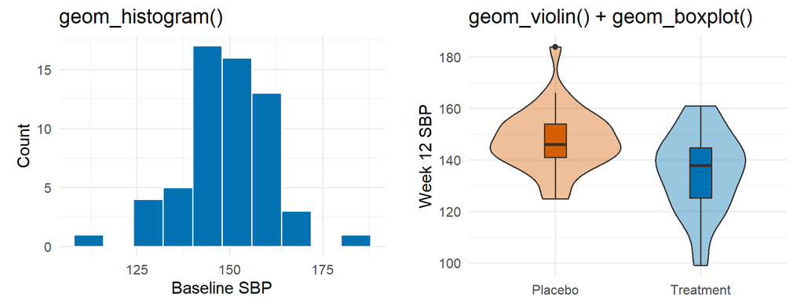

The histogram groups observations into numeric bins. A violin describes a smoothed distribution, while the overlaid box marks its quartiles and median.

## Geom reference: bars and filled regions

| Function | Purpose |
| --- | --- |
| `geom_bar()` | Count records by category by default |
| `geom_col()` | Draw supplied y values as bar heights |
| `geom_area()` | Filled region to a baseline, stacked by default |
| `geom_ribbon()` | Region between supplied ymin and ymax |
| `geom_rect()` | Rectangles defined by boundary coordinates |
| `geom_tile()` | Rectangles defined by centres and dimensions |
| `geom_raster()` | Efficient equal-sized rectangular cells |

## Geom examples: bars and a ribbon

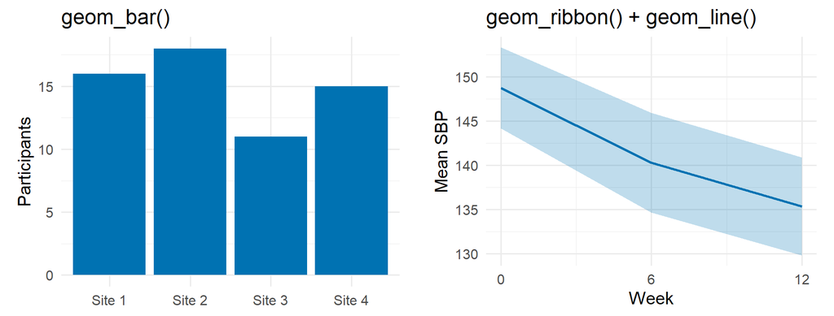

Bars show counts. The ribbon fills a supplied lower-to-upper range, here approximate 95% intervals for the treatment-arm mean at each visit.

## Geom reference: intervals

| Function | Purpose |
| --- | --- |
| `geom_pointrange()` | Point estimate and interval |
| `geom_linerange()` | Interval alone |
| `geom_errorbar()` | Interval with end caps |
| `geom_crossbar()` | Central value across an interval box |
| `geom_errorbarh()` | Older horizontal error-bar interface (deprecated) |

For new horizontal error bars, use `geom_errorbar(orientation = "y")` with `xmin` and `xmax`. The plotting function does not determine whether your interval means SD, SE, or a confidence interval.

## Geom examples: two ways to draw an interval

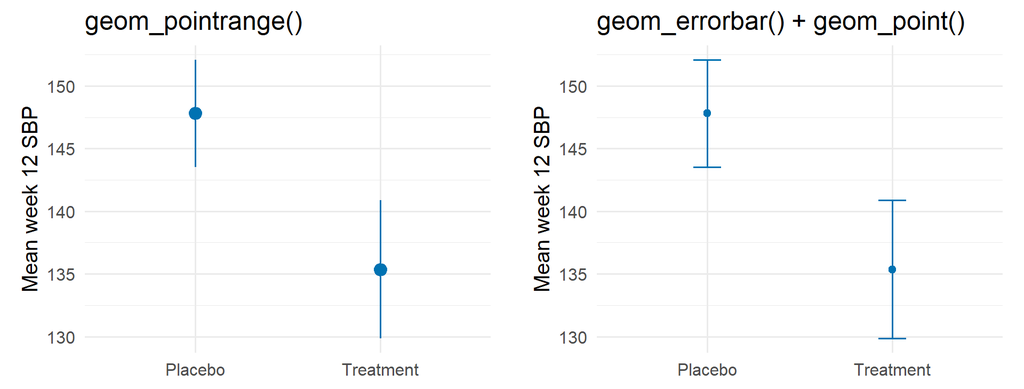

These show the same means and approximate 95% confidence intervals. Pointrange draws both marks; errorbar supplies the interval with end caps.

## Geom reference: fits and reference lines

| Function | Purpose |
| --- | --- |
| `geom_smooth()` | Fitted trend with an optional uncertainty band |
| `geom_quantile()` | Conditional quantile regression lines |
| `geom_function()` | Evaluate and draw a supplied function |
| `geom_abline()` | Lines specified by intercept and slope |
| `geom_hline()` | Horizontal reference lines |
| `geom_vline()` | Vertical reference lines |
| `geom_blank()` | Invisible layer, useful for establishing scale ranges |

## Geom examples: fitted and reference lines

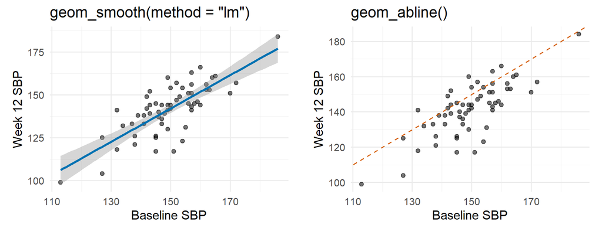

The fitted line summarizes a relationship in the data. The identity line marks equality between visits and needs no fitted model.

## Geom reference: two-dimensional patterns

| Function | Purpose |
| --- | --- |
| `geom_bin_2d()` | Counts in rectangular x/y bins |
| `geom_hex()` | Counts in hexagonal x/y bins |
| `geom_density_2d()` | Contours of an estimated x/y density |
| `geom_density_2d_filled()` | Filled regions of an estimated x/y density |
| `geom_contour()` | Contour lines for supplied grid values z |
| `geom_contour_filled()` | Filled contour regions for supplied grid values z |

`geom_hex()` needs the **hexbin** package. Counts, estimated densities, and supplied surface values answer different questions.

## Geom examples: binned counts and contours

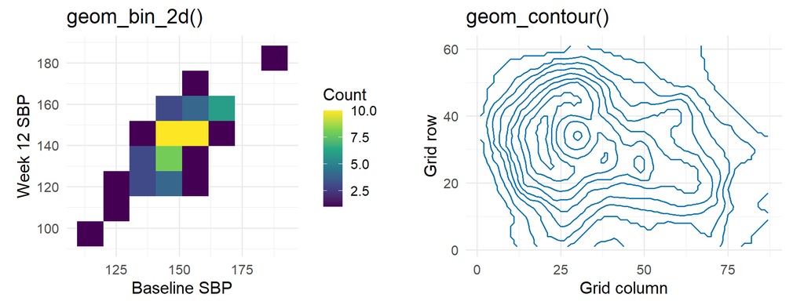

Left: counts of participants in x/y bins. Right: equal-value lines from R’s built-in `volcano` elevation grid. Contours require surface values, not just x/y pairs.

## Geom reference: maps and shapes

| Function | Purpose |
| --- | --- |
| `geom_polygon()` | Closed shapes from ordered vertices |
| `geom_map()` | Values joined to a separate map polygon table |
| `geom_sf()` | Geometry from an sf spatial object |
| `geom_sf_text()` | Text located using sf geometry |
| `geom_sf_label()` | Boxed text located using sf geometry |

The `geom_sf*()` functions use the **sf** package and spatial data structures. Spatial analysis is outside this session’s core material.

## Geom example: regions defined by vertices

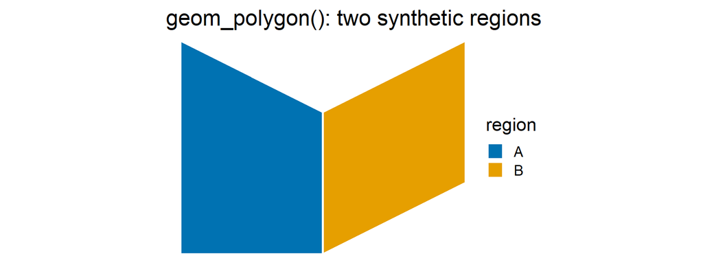

Each group supplies one shape’s vertices in boundary order. Real geographic work commonly uses `geom_sf()` with spatial geometry instead of hand-entered vertices.

## Geom reference: aliases and package version

| Function | Purpose |
| --- | --- |
| `geom_bin2d()` | Alias of geom_bin_2d |
| `geom_density2d()` | Alias of geom_density_2d |
| `geom_density2d_filled()` | Alias of geom_density_2d_filled |

This deck lists **53 exported names**, including aliases, for **ggplot2 4.0.0**.

Use `?geom_point` or the [official reference](https://ggplot2.tidyverse.org/reference/index.html) for arguments. Newer releases may add functions. There is no need to install an extension package just to complete the core examples.

## Back to the study: distributions

The catalogue shows the range of available marks. Now we use a small set to answer the study questions.

**First question:** What is the distribution of baseline SBP?

Compare a histogram’s bins with a density curve’s smoothing.

## Distributions: histogram and density

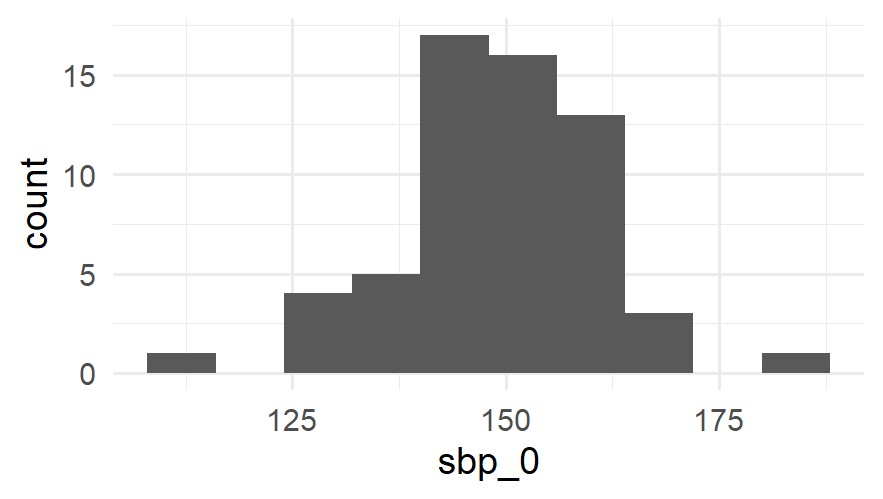

```r
ggplot(trial, aes(sbp_0)) +
  geom_histogram(binwidth = 8,
                 fill = "grey35")
```

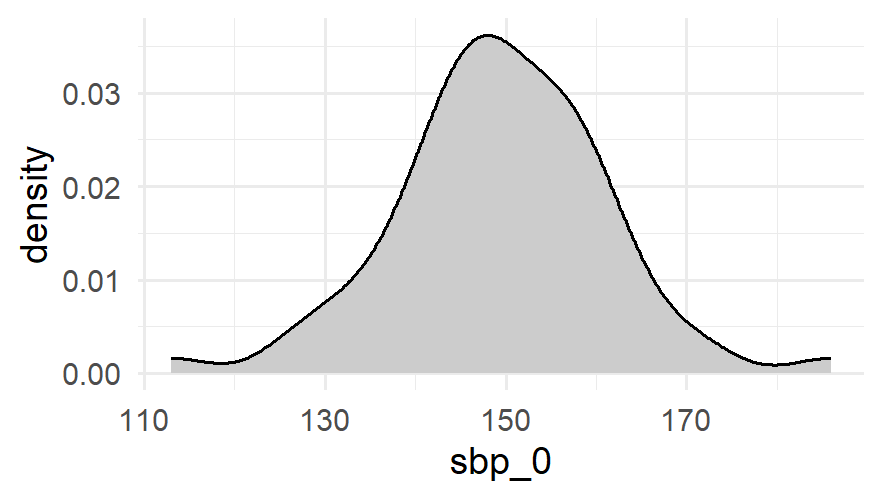

```r
ggplot(trial, aes(sbp_0)) +
  geom_density(fill = "grey80")
```

`binwidth = 8` uses 8-mmHg bins. `bins = 30` asks for a number of bins. Either choice needs checking: try alternatives and see whether the pattern persists.

**The base R way:** `hist(trial$sbp_0)` · `plot(density(trial$sbp_0))`

## Distributions compared: boxplot and violin

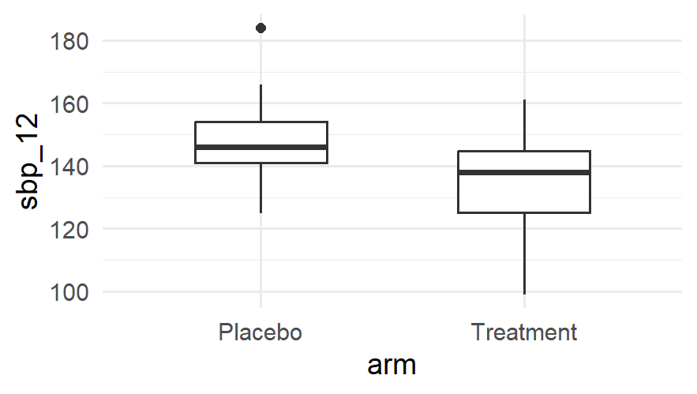

```r
ggplot(trial, aes(arm, sbp_12)) +
  geom_boxplot(width = 0.5)
```

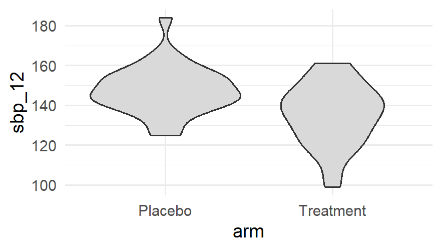

```r
ggplot(trial, aes(arm, sbp_12)) +
  geom_violin(fill = "grey85")
```

A boxplot shows the median, quartiles, whiskers, and possible outlying points. A violin shows an estimated density. Neither displays the sample size by default.

**The base R way:** `boxplot(sbp_12 ~ arm, data = trial)`

## Show the data, not only the summary

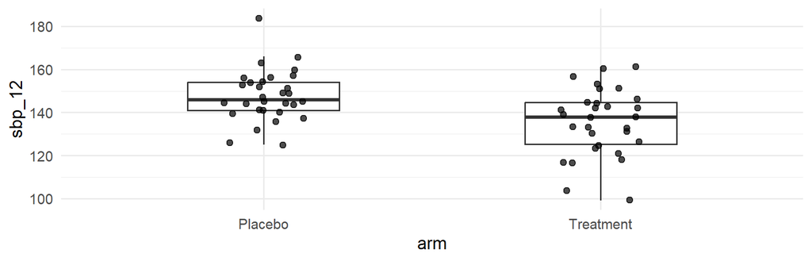

```r
ggplot(trial, aes(arm, sbp_12)) +
  geom_boxplot(width = 0.45, outlier.shape = NA) +
  geom_jitter(width = 0.12, alpha = 0.7, size = 2)
```

`outlier.shape = NA` stops the boxplot drawing outliers that `geom_jitter()` already drew. Two marks for one observation is a real error, not a style choice.

## Sixty participants, fewer visible dots?

60 SECONDS · THINK, THEN VOTE

Our scatterplot contains **60 participants**.

Could it show fewer than 60 separately visible dots?

**A.** Yes, observations can overlap

**B.** No, R always separates the points

**C.** Only if some participants were removed

**A.** Multiple observations can occupy the same or nearby plotting positions.

Transparency or suitable jitter can help reveal overlap.

## Overlap can hide observations

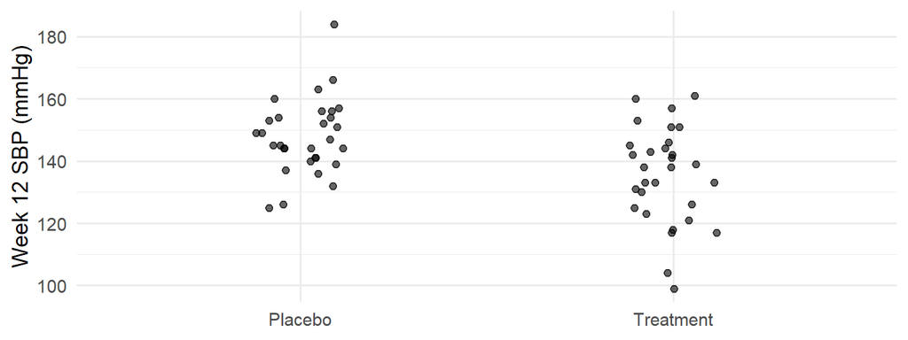

```r
ggplot(trial, aes(arm, sbp_12)) +
  geom_point(position = position_jitter(width = 0.12,
                                        height = 0, seed = 6301),
             alpha = 0.6) +
  labs(x = NULL, y = "Week 12 SBP (mmHg)")
```

Horizontal jitter separates tied marks. `height = 0` preserves the measured outcome, and `seed` makes the offsets repeatable. Alpha reduces visual overlap.

## Counts versus a precomputed table

| arm | n |
| --- | --- |
| Placebo | 30 |
| Treatment | 30 |

```r
# One row per participant: let the geom count
ggplot(trial, aes(arm)) + geom_bar()

# One row per arm: heights are already calculated
ggplot(counts, aes(arm, n)) + geom_col()
```

Both give the same counts here. A mean or percentage already stored in `y` usually calls for `geom_col()`, not the default `geom_bar()` statistic.

## Comparisons: bars, and position adjustments

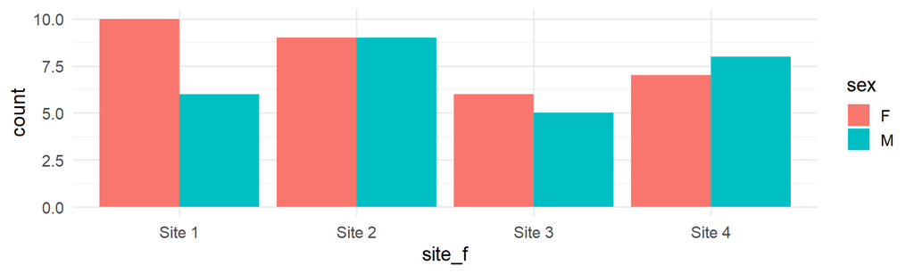

```r
ggplot(trial, aes(site_f, fill = sex)) +
  geom_bar(position = "dodge")
```

| `position =` | Shows | Good for |
| --- | --- | --- |
| `"stack"` *(default)* | Counts, one bar per group | Totals |
| `"dodge"` | Counts, side by side | Comparing subgroups |
| `"fill"` | Proportions, all bars to 1 | Composition — but hides n |